# Annotation of resistance genes/determintants

Query: GCF_000240185.1_ASM24018v2_genomic

Produced with bacannot pipeline

08 September 2020

# 1 About

Resistance genes or resistance determinants confer to the bacteria the ability to tolerate or resist some antibiotics or antimicrobials. Which means, these characteristics makes the bacteria less susceptible to its effects. Resistance determinants were predicted using [AMRFinderPlus](https://github.com/ncbi/amr/wiki) and [CARD RGI](https://github.com/arpcard/rgi). Additionally, we scanned the genome with [ARGminer](https://bench.cs.vt.edu/argminer/#/home) database which is an online resource for the inspection and curation of ARGs based on crowdsourcing as well as a platform to promote interaction and collaboration for the ARG scientific community.

[AMRFinderPlus](https://github.com/ncbi/amr/wiki) is a binary distributed by NCBI that allows users to query the National Database of Antibiotic Resistant Organisms ([NDARO](https://www.ncbi.nlm.nih.gov/pathogens/antimicrobial-resistance/)). This is a NCBI curated database that aggregates resistance genes from other databases such as [Resfams](http://www.dantaslab.org/resfams), [CARD](https://card.mcmaster.ca/), ResFinder, Pasteur Institute Beta Lactamases and others. For more information please read the following [link](https://www.ncbi.nlm.nih.gov/bioproject/PRJNA313047). NCBI’s efforts were done in order to standardize and confer reliability to AMR predictions.

[CARD RGI](https://github.com/arpcard/rgi) is a tool which enables the detection of new variants and mutations that confer resistance to antibiotics, it analyzes genome or proteome sequences under three paradigms: **Perfect**, **Strict**, and **Loose** (a.k.a. Discovery). **The Perfect algorithm** is most often applied to clinical surveillance as it detects perfect matches to the curated reference sequences and mutations in the CARD. In contrast, **the Strict algorithm** detects previously unknown variants of known AMR genes, including secondary screen for key mutations, using detection models with CARD’s curated similarity cut-offs to ensure the detected variant is likely a functional AMR gene.

[ARGminer](https://bench.cs.vt.edu/argminer/#/home) is used in the workflow in order to provide some more diverse insights about the resistance genes found. It can not be used as the sole source of prediction, but it may be a useful contribution for analyses and AMR descriptions because it tries to aggregate and create nomenclature standards between databases.

About the BLASTs:

- [AMRFinderPlus](https://github.com/ncbi/amr/wiki) and [ARGminer](https://bench.cs.vt.edu/argminer/#/home) are searched in a manner that it is possible to filter alignments based on coverage and identity, for those we have used the following:
  - Blast % identity: `> 90%`
  - Blast % query coverage: `> 90%`
    - For blasts against gene sequences predicted by Prokka, alignments are filtered in a two way manner so they cover at least 90% of the reference gene sequence and the of query sequence at the same time – *valid for ARGminer*
- [CARD RGI](https://github.com/arpcard/rgi) results are not filtered in these manners because they have their own detection models thresholds obtained by curation

# 2 AMRFinder

Below it is summarized the results obtained with AMRFinderPlus. Roughly, it can be divided into two main categories:

1. Genes related to antibiotics, called AMR;
2. Genes related to stress resistance which can be:
   - biocide resistance
   - metal resistance
   - heat resistance

This is well documented in Table 2.1. Whenever possible, all feature have links to NCBI database marking the closest reference sequence to each annotated gene. Additionally, gene targets are summarized in image 2.1. Right below it is presented a small list containing AMR genes found in the query genome. If empty, none has been found.

- **AMR genes found in the query genome:**
  - fosA
  - kdeA
  - blaSHV-11
  - emrD
  - blaCTX-M-14
  - blaKPC-2
  - blaTEM-1
  - rmtB1
  - tet(G)
  - floR2
  - aadA2
  - aac(3)
  - aph(6)-Id
  - aph(3’’)-Ib
  - sul2

## 2.1 Supporting Data

Table 2.1: Resistance genes annotated from NCBI AMR curated database using AMRfinderplus

|  | Resistance type | Resistance subtype | Query protein | Gene | Product | Resistance Class | Resistance subclass | Detection method | Ref. Accession | Genomic coordinates |
| --- | --- | --- | --- | --- | --- | --- | --- | --- | --- | --- |
| 1 | AMR | AMR | PFHEFCNI_00606 | fosA | FosA family fosfomycin resistance glutathione transferase | FOSFOMYCIN | FOSFOMYCIN | BLASTP | WP_004146118.1 | NC_016845.1:646217-646636 |
| 2 | AMR | AMR | PFHEFCNI_01693 | kdeA | multidrug efflux MFS transporter KdeA | EFFLUX | EFFLUX | BLASTP | ABR76310.1 | NC_016845.1:1774337-1775569 |
| 3 | AMR | AMR | PFHEFCNI_02468 | blaSHV-11 | class A broad-spectrum beta-lactamase SHV-11 | BETA-LACTAM | BETA-LACTAM | ALLELEP | WP_004176269.1 | NC_016845.1:2549403-2550263 |
| 4 | AMR | AMR | PFHEFCNI_05115 | emrD | multidrug efflux MFS transporter EmrD | EFFLUX | EFFLUX | BLASTP | ACN65732.1 | NC_016845.1:5268974-5270158 |
| 5 | AMR | AMR | PFHEFCNI_05206 | blaCTX-M-14 | class A extended-spectrum beta-lactamase CTX-M-14 | BETA-LACTAM | CEPHALOSPORIN | ALLELEP | WP_001617865.1 | NC_016838.1:31843-32718 |
| 6 | AMR | AMR | PFHEFCNI_05333 | blaKPC-2 | carbapenem-hydrolyzing class A beta-lactamase KPC-2 | BETA-LACTAM | CARBAPENEM | ALLELEP | WP_004199234.1 | NC_016846.1:20557-21438 |
| 7 | AMR | AMR | PFHEFCNI_05351 | blaTEM-1 | class A broad-spectrum beta-lactamase TEM-1 | BETA-LACTAM | BETA-LACTAM | ALLELEP | WP_000027057.1 | NC_016846.1:41723-42583 |
| 8 | AMR | AMR | PFHEFCNI_05480 | blaTEM-1 | class A broad-spectrum beta-lactamase TEM-1 | BETA-LACTAM | BETA-LACTAM | ALLELEP | WP_000027057.1 | NC_016839.1:29746-30606 |
| 9 | AMR | AMR | PFHEFCNI_05481 | rmtB1 | 16S rRNA (guanine(1405)-N(7))-methyltransferase RmtB1 | AMINOGLYCOSIDE | AMINOGLYCOSIDE | ALLELEP | WP_012372818.1 | NC_016839.1:30776-31531 |
| 10 | AMR | AMR | PFHEFCNI_05487 | tet(G) | tetracycline efflux MFS transporter Tet(G) | TETRACYCLINE | TETRACYCLINE | EXACTP | WP_001257840.1 | NC_016839.1:35237-36412 |

[output cut: 21 more lines]

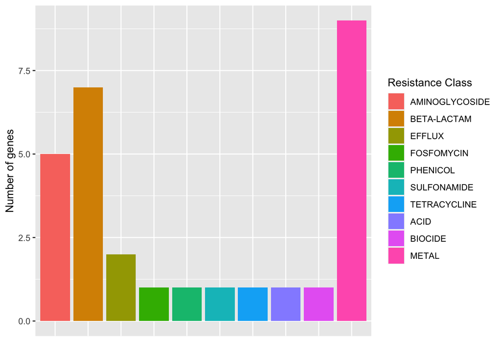

Figure 2.1: Resistome Predicted using NCBI’s AMRFinderplus

# 3 CARD RGI

Below it is summarized the results obtained with RGI. Roughly, it can be divided into two main categories:

1. Perfect hits
   - detects perfect matches to the curated reference sequences and mutations in the CARD
2. Strict hits
   - detects previously unknown variants of known AMR genes, including secondary screen for key mutations, using detection models with CARD’s curated similarity cut-offs to ensure the detected variant is likely a functional AMR gene

**Obs:** CARD RGI tool always tries to annotate functional AMR genes, however, depending on the assembly, a not functional gene may yet be annotated. There for, users are advised to double check genes annotated under **Strict** category.

## 3.1 Perfect hits

Perfect hits are genes that CARD guarantee its functionality. Which means that these genes are likely functional and might be conferring resistance to the bacteria. The drug classes found to be targeted by the AMR genes found are shown below:

- **Drug Classes targeted by the query genome:**
  - aminoglycoside antibiotic
  - carbapenem
  - cephalosporin
  - macrolide antibiotic
  - monobactam
  - No specific target
  - penam
  - penem
  - peptide antibiotic
  - rifamycin antibiotic
  - sulfonamide antibiotic
  - tetracycline antibiotic

### 3.1.1 AMR genes

|  | Prokka_ID | Product | AMR Gene Family | Resistance Mechanism | Drug Class | CVTERM.ID | Query Protein Coordinates |
| --- | --- | --- | --- | --- | --- | --- | --- |
| 1 | PFHEFCNI_05503 | sul2 | sulfonamide resistant sul | antibiotic target replacement | sulfonamide antibiotic | 36551 | NC_016839.1:52795-53610 |
| 2 | PFHEFCNI_05481 | rmtB | 16S rRNA methyltransferase (G1405) | antibiotic target alteration | aminoglycoside antibiotic | 37240 | NC_016839.1:30776-31531 |
| 3 | PFHEFCNI_05480 | TEM-1 | TEM beta-lactamase | antibiotic inactivation | monobactam; cephalosporin; penam; penem | 37253 | NC_016839.1:29746-30606 |
| 4 | PFHEFCNI_05500 | TEM-1 | TEM beta-lactamase | antibiotic inactivation | monobactam; cephalosporin; penam; penem | 37253 | NC_016839.1:49820-50680 |
| 5 | PFHEFCNI_05351 | TEM-1 | TEM beta-lactamase | antibiotic inactivation | monobactam; cephalosporin; penam; penem | 37253 | NC_016846.1:41723-42583 |
| 6 | PFHEFCNI_02468 | SHV-11 | SHV beta-lactamase | antibiotic inactivation | carbapenem; cephalosporin; penam | 37450 | NC_016845.1:2549403-2550263 |
| 7 | PFHEFCNI_05206 | CTX-M-14 | CTX-M beta-lactamase | antibiotic inactivation | cephalosporin | 38277 | NC_016838.1:31843-32718 |
| 8 | PFHEFCNI_05538 | CTX-M-14 | CTX-M beta-lactamase | antibiotic inactivation | cephalosporin | 38277 | NC_016839.1:82527-83402 |
| 9 | PFHEFCNI_05333 | KPC-2 | KPC beta-lactamase | antibiotic inactivation | monobactam; carbapenem; cephalosporin; penam | 38712 | NC_016846.1:20557-21438 |
| 10 | PFHEFCNI_05492 | aadA2 | ANT(3'') | antibiotic inactivation | aminoglycoside antibiotic | 39002 | NC_016839.1:40256-41035 |

[output cut: 4 more lines]

The images 3.1 and 3.2 summarises the drug classes targeted by the AMR genes found and its resistance mechanisms.

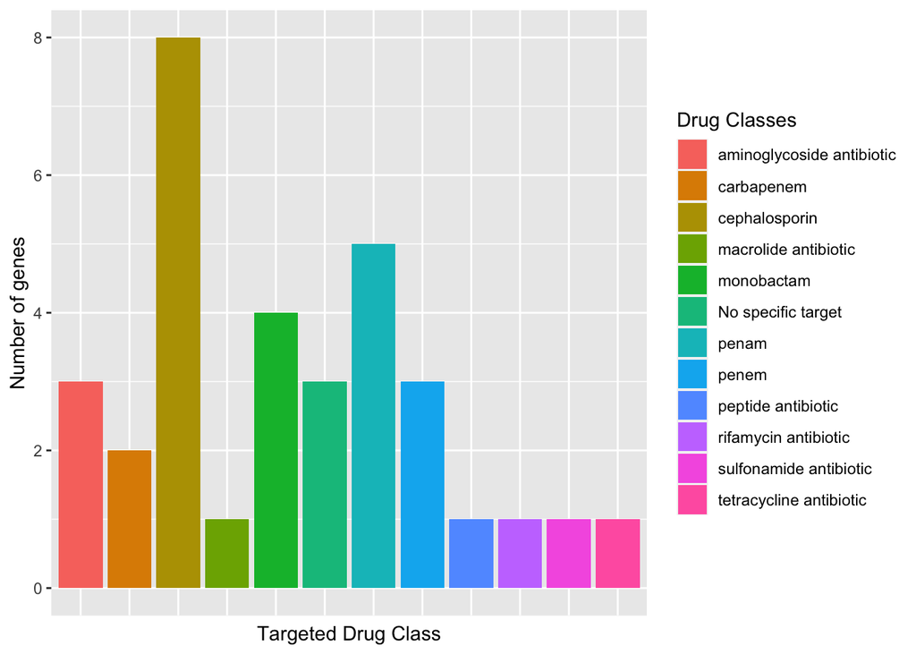

Figure 3.1: Resistome Predicted using CARD RGI tool

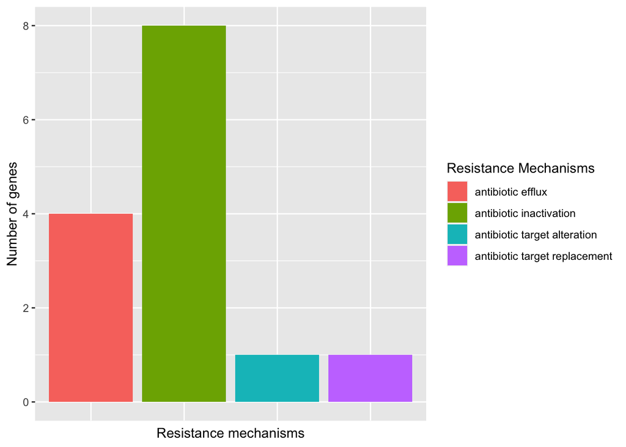

Figure 3.2: Resistome Predicted using CARD RGI tool

## 3.2 Strict hits

Strict hits genes are genes annotated with looser parameters and are not surely functional or correct. Which means, users should double check genes under this category. The drug classes found to be targeted by the AMR genes found are shown below:

- **Drug Classes targeted by the query genome:**
  - aminocoumarin antibiotic
  - aminoglycoside antibiotic
  - benzalkonium chloride
  - carbapenem
  - cephalosporin
  - cephamycin
  - diaminopyrimidine antibiotic
  - elfamycin antibiotic
  - fluoroquinolone antibiotic
  - fosfomycin
  - glycylcycline
  - macrolide antibiotic
  - monobactam
  - nitroimidazole antibiotic
  - penam
  - penem
  - peptide antibiotic
  - phenicol antibiotic
  - rhodamine
  - rifamycin antibiotic
  - tetracycline antibiotic
  - triclosan

### 3.2.1 AMR genes

|  | Prokka_ID | Product | AMR Gene Family | Resistance Mechanism | Drug Class | CVTERM.ID | Query Protein Coordinates |
| --- | --- | --- | --- | --- | --- | --- | --- |
| 1 | PFHEFCNI_05487 | tet(D) | major facilitator superfamily (MFS) antibiotic efflux pump | antibiotic efflux | tetracycline antibiotic | 36307 | NC_016839.1:35237-36412 |
| 2 | PFHEFCNI_01170 | acrB | resistance-nodulation-cell division (RND) antibiotic efflux pump | antibiotic efflux | fluoroquinolone antibiotic; cephalosporin; glycylcycline; penam; tetracycline antibiotic; rifamycin antibiotic; phenicol antibiotic; triclosan | 36355 | NC_016845.1:1241191-1244337 |
| 3 | PFHEFCNI_02492 | marA | resistance-nodulation-cell division (RND) antibiotic efflux pump; General Bacterial Porin with reduced permeability to beta-lactams | antibiotic efflux; reduced permeability to antibiotic | fluoroquinolone antibiotic; monobactam; carbapenem; cephalosporin; glycylcycline; cephamycin; penam; tetracycline antibiotic; rifamycin antibiotic; phenicol antibiotic; triclosan; penem | 36402 | NC_016845.1:2572025-2572399 |
| 4 | PFHEFCNI_03775 | acrD | resistance-nodulation-cell division (RND) antibiotic efflux pump | antibiotic efflux | aminoglycoside antibiotic | 36630 | NC_016845.1:3905323-3908436 |
| 5 | PFHEFCNI_03984 | emrR | major facilitator superfamily (MFS) antibiotic efflux pump | antibiotic efflux | fluoroquinolone antibiotic | 36655 | NC_016845.1:4118968-4119498 |
| 6 | PFHEFCNI_04771 | CRP | resistance-nodulation-cell division (RND) antibiotic efflux pump | antibiotic efflux | macrolide antibiotic; fluoroquinolone antibiotic; penam | 36657 | NC_016845.1:4888902-4889534 |
| 7 | PFHEFCNI_03496 | mdtB | resistance-nodulation-cell division (RND) antibiotic efflux pump | antibiotic efflux | aminocoumarin antibiotic | 37173 | NC_016845.1:3597230-3600352 |
| 8 | PFHEFCNI_03497 | mdtC | resistance-nodulation-cell division (RND) antibiotic efflux pump | antibiotic efflux | aminocoumarin antibiotic | 37174 | NC_016845.1:3600353-3603430 |
| 9 | PFHEFCNI_03500 | baeR | resistance-nodulation-cell division (RND) antibiotic efflux pump | antibiotic efflux | aminoglycoside antibiotic; aminocoumarin antibiotic | 37208 | NC_016845.1:3606319-3607041 |
| 10 | PFHEFCNI_01693 | Escherichia coli mdfA | major facilitator superfamily (MFS) antibiotic efflux pump | antibiotic efflux | tetracycline antibiotic; benzalkonium chloride; rhodamine | 37727 | NC_016845.1:1774337-1775569 |

[output cut: 21 more lines]

The images 3.3 and 3.4 summarises the drug classes targeted by the AMR genes found and its resistance mechanisms.

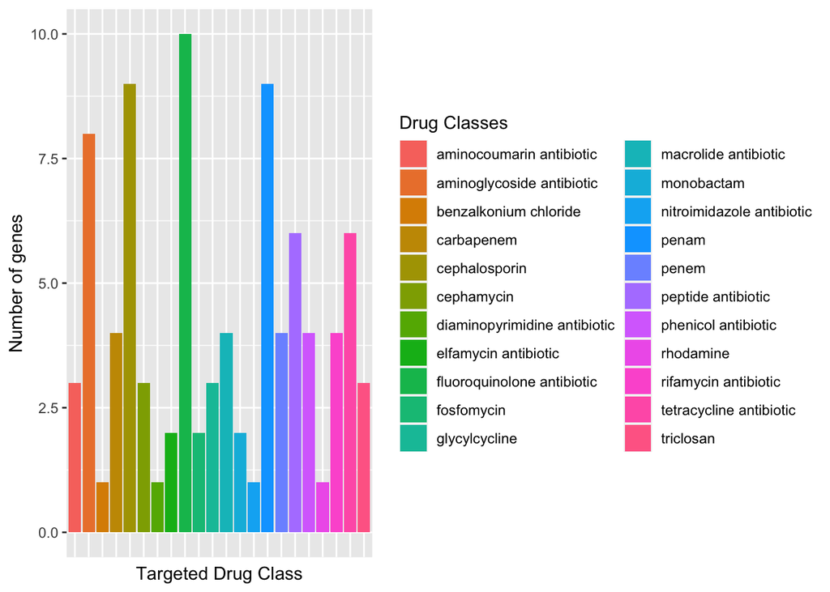

Figure 3.3: Resistome Predicted using CARD RGI tool

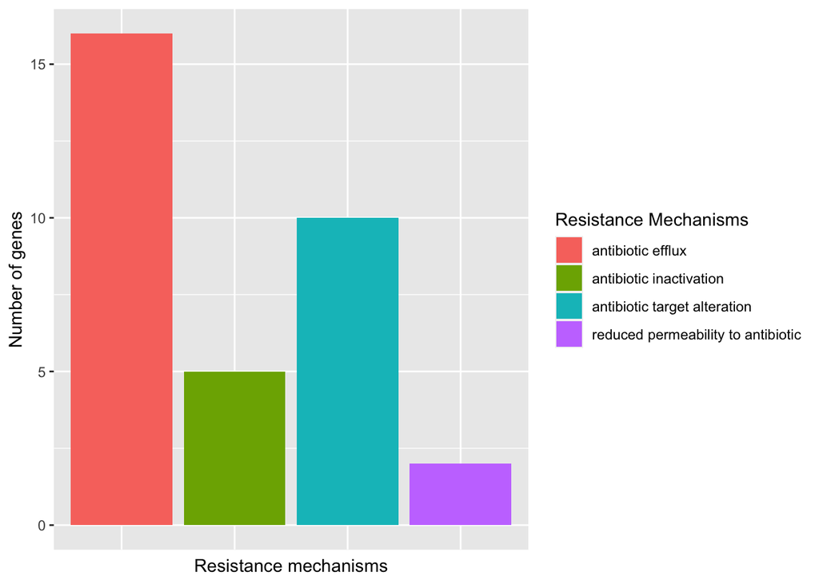

Figure 3.4: Resistome Predicted using CARD RGI tool

# 4 ARGminer

ARGminer is an online resource for the inspection and curation of ARGs based on crowdsourcing as well as a platform to promote interaction and collaboration for the ARG scientific community. We put this database here in the report and annotation in order to support the initative and to help it go towards nomenclature simplification. Genes are scanned via BLASTp since ARGminer is a protein-only database. This alignment is summarized in table 4.1.

> It must be used with caution. Remender, it is a super new database thus it is rapidly changing and may yet contain errors.

### 4.0.1 BLAST summary

Table 4.1: Resistance genes detected using ARGminer database via BLASTp

|  | Protein ID | Start | End | Strand | Gene Name | Coverage Map | Gaps | Coverage % | Identity % | Reference | Drug target |
| --- | --- | --- | --- | --- | --- | --- | --- | --- | --- | --- | --- |
| 1 | PFHEFCNI_00075 | 1 | 457 | + | cpxA | 1-457/457 | 0/0 | 100 | 90.4 | NP_312864.1 | multidrug |
| 2 | PFHEFCNI_00076 | 1 | 232 | + | Pseudomonas aeruginosa CpxR | 1-232/232 | 0/0 | 100 | 100 | CP000647.1.gene4257.p01 | macrolide;fluoroquinolone;monobactam;aminoglycoside;carbapenem;cephalosporin;cephamycin;penam;tetracycline;peptide;aminocoumarin;diaminopyrimidine;sulfonamide;phenicol;penem |
| 3 | PFHEFCNI_00320 | 1 | 152 | + | Escherichia coli soxR with mutation conferring antibiotic resistance | 1-152/154 | 0/0 | 98.7 | 90.1 | AAC77033.1 | fluoroquinolone;cephalosporin;glycylcycline;penam;tetracycline;rifamycin;phenicol;triclosan |
| 4 | PFHEFCNI_00606 | 1 | 139 | + | FosA6 | 1-139/139 | 0/0 | 100 | 98.6 | WP_004146118.1 | fosfomycin |
| 5 | PFHEFCNI_00759 | 1 | 273 | + | KsgA | 1-273/273 | 0/0 | 100 | 100 | BAH61691 | kasugamycin |
| 6 | PFHEFCNI_01042 | 1 | 386 | + | ampH | 1-386/386 | 0/0 | 100 | 99.7 | (Bla)ampH:CP003785:4208384-4209544:1161 | beta_lactam |
| 7 | PFHEFCNI_01170 | 1 | 1048 | + | acrB | 1-1048/1048 | 0/0 | 100 | 100 | CP000647.1.gene443.p01 | fluoroquinolone;cephalosporin;glycylcycline;penam;tetracycline;rifamycin;phenicol;triclosan |
| 8 | PFHEFCNI_01171 | 1 | 397 | + | Klebsiella pneumoniae acrA | 21-417/417 | 0/0 | 95.2 | 99.7 | CDI16885.1 | fluoroquinolone;cephalosporin;glycylcycline;penam;tetracycline;rifamycin;phenicol;triclosan |
| 9 | PFHEFCNI_01371 | 1 | 113 | + | ramA | 12-124/124 | 0/0 | 91.13 | 92 | AFK13828.1 | multidrug |
| 10 | PFHEFCNI_01485 | 1 | 632 | + | penA | 1-632/633 | 0/0 | 99.84 | 93.4 | (Bla)Penicillin_Binding_Protein_Ecoli:CP002291:664439-666340:1902 | beta-lactam |

[output cut: 49 more lines]

# 5 Prokka

Additionally, Prokka generically annotates a few proteins that are related to any type of resistance. One must take caution when evaluating this result because this annotation can be very generic and therefore not so meaningful. Because it uses hmms, it can happen to annotate a multidrug resistance efflux pumps but it must be checked whether it is correctly annotated or functional. These are showed in Table 5.1.

Table 5.1: Generic annotation of resistance determinants by Prokka

|  | Contig | Start | End | Description |
| --- | --- | --- | --- | --- |
| 1 | NC_016838.1 | 31843 | 32718 | ID=PFHEFCNI_05206;eC_number=3.5.2.6;Name=bla_2;gene=bla_2;inference=ab initio prediction:Prodigal:002006,similar to AA sequence:UniProtKB:E1ANH6;locus_tag=PFHEFCNI_05206;product=Beta-lactamase CTX-M-9… |
| 2 | NC_016839.1 | 29746 | 30606 | ID=PFHEFCNI_05480;eC_number=3.5.2.6;Name=bla_5;gene=bla_5;inference=ab initio prediction:Prodigal:002006,similar to AA sequence:UniProtKB:P62593;locus_tag=PFHEFCNI_05480;product=Beta-lactamase TEM;Add… |
| 3 | NC_016839.1 | 30776 | 31531 | ID=PFHEFCNI_05481;eC_number=2.1.1.179;Name=rmtB;gene=rmtB;inference=ab initio prediction:Prodigal:002006,similar to AA sequence:UniProtKB:Q76G15;locus_tag=PFHEFCNI_05481;product=16S rRNA (guanine(1405… |
| 4 | NC_016839.1 | 35237 | 36412 | ID=PFHEFCNI_05487;Name=tetA;gene=tetA;inference=ab initio prediction:Prodigal:002006,similar to AA sequence:UniProtKB:P02981;locus_tag=PFHEFCNI_05487;product=Tetracycline resistance protein%2C class C… |
| 5 | NC_016839.1 | 37349 | 38563 | ID=PFHEFCNI_05489;Name=ydhC_2;gene=ydhC_2;inference=ab initio prediction:Prodigal:002006,similar to AA sequence:UniProtKB:P37597;locus_tag=PFHEFCNI_05489;product=Inner membrane transport protein YdhC;… |
| 6 | NC_016839.1 | 39745 | 40092 | ID=PFHEFCNI_05491;Name=emrE;db_xref=COG:COG2076;gene=emrE;inference=ab initio prediction:Prodigal:002006,similar to AA sequence:UniProtKB:P23895;locus_tag=PFHEFCNI_05491;product=Multidrug transporter … |
| 7 | NC_016839.1 | 40256 | 41035 | ID=PFHEFCNI_05492;eC_number=2.7.7.47;Name=ant1;gene=ant1;inference=ab initio prediction:Prodigal:002006,similar to AA sequence:UniProtKB:P0A0D1;locus_tag=PFHEFCNI_05492;product=Streptomycin 3''-adenyl… |
| 8 | NC_016839.1 | 44155 | 44850 | ID=PFHEFCNI_05495;eC_number=2.3.1.-;Name=yokD;db_xref=COG:COG2746;gene=yokD;inference=ab initio prediction:Prodigal:002006,similar to AA sequence:UniProtKB:O32003;locus_tag=PFHEFCNI_05495;product=SPbe… |
| 9 | NC_016839.1 | 44863 | 45405 | ID=PFHEFCNI_05496;Name=tmrB;gene=tmrB;inference=ab initio prediction:Prodigal:002006,similar to AA sequence:UniProtKB:P12921;locus_tag=PFHEFCNI_05496;product=Tunicamycin resistance protein |
| 10 | NC_016839.1 | 49820 | 50680 | ID=PFHEFCNI_05500;eC_number=3.5.2.6;Name=bla_6;gene=bla_6;inference=ab initio prediction:Prodigal:002006,similar to AA sequence:UniProtKB:P62593;locus_tag=PFHEFCNI_05500;product=Beta-lactamase TEM;Add… |

[output cut: 78 more lines]